# Introduction to R

Introduction to R Marcelo Guarido de Andrade

This `Rmarkdowm` is presenting an introduction to R. We are going start from the simple math operations and will go up to using [python](https://www.python.org/) inside `R`.

## Simple operations

`R` can be used as a calculator. We can add, subtract, multiply, divide, and do more complex math operations very easily.

```r
1 + 1
```

```
## [1] 2
```

```r
2 - 1
```

```
## [1] 1
```

```r
3 * 2
```

```
## [1] 6
```

```r
9 / 3
```

```
## [1] 3
```

```r
2 ** 5
```

```
## [1] 32
```

In base `R`, there are some more complex functions for other types of operations.

```r
sqrt(144)
```

```
## [1] 12
```

```r
pi
```

```
## [1] 3.141593
```

```r
sqrt(pi)
```

```
## [1] 1.772454
```

We can make operations on objects.

```r
a <- 3
b <- 5
c <- pi

x <- (a - b) * sinpi(c)
print(x)
```

```
## [1] 0.8606024
```

## Lists and arrays

In `R`, there is not a big difference between lists and arrays. Actually, they have the same properties.

```r
x <- list(1, 2, 3, 4)
print(paste0("List:", x))
```

```
## [1] "List:1" "List:2" "List:3" "List:4"
```

```r
print(x[2])
```

```
## [[1]]
## [1] 2
```

```r
as.array(x)
```

```
## [[1]]
## [1] 1
##
## [[2]]
## [1] 2
##
## [[3]]
## [1] 3
##
## [[4]]
## [1] 4
```

What happens if we set each element of a list to be a data frame?

```r
x = list(iris, cars)
```

Now, converting the list to array:

```r
y = as.array(x)
```

Both are understood as a list.

## How to install a package?

In [RStudio](https://rstudio.com/), there are several ways to install a package.

- Go to the tab *Packages* and select *Install*
- Go to *Tools* and select *Install packages*
- Or from the R command `install.packages`

```r
install.packages("DT")
```

## Importing installed packages

To import libraries to your work environment, use the function `library`.

```r
library("DT")
```

Let’s load a `csv` file from the disk:

```r
data <- read.csv("data/FL_insurance_sample.csv")
head(data)
```

```
##   policyID statecode      county eq_site_limit hu_site_limit fl_site_limit
## 1   119736        FL CLAY COUNTY      498960.0     498960.00      498960.0
## 2   448094        FL CLAY COUNTY     1322376.3    1322376.30     1322376.3
## 3   206893        FL CLAY COUNTY      190724.4     190724.40      190724.4
## 4   333743        FL CLAY COUNTY           0.0      79520.76           0.0
## 5   172534        FL CLAY COUNTY           0.0     254281.50           0.0
## 6   785275        FL CLAY COUNTY           0.0     515035.62           0.0
##   fr_site_limit   tiv_2011   tiv_2012 eq_site_deductible hu_site_deductible
## 1      498960.0  498960.00  792148.90                  0             9979.2
## 2     1322376.3 1322376.30 1438163.57                  0                0.0
## 3      190724.4  190724.40  192476.78                  0                0.0
## 4           0.0   79520.76   86854.48                  0                0.0
## 5      254281.5  254281.50  246144.49                  0                0.0
## 6           0.0  515035.62  884419.17                  0                0.0
##   fl_site_deductible fr_site_deductible point_latitude point_longitude
## 1                  0                  0       30.10226       -81.71178
## 2                  0                  0       30.06394       -81.70766
## 3                  0                  0       30.08958       -81.70046
## 4                  0                  0       30.06324       -81.70770
## 5                  0                  0       30.06061       -81.70267
## 6                  0                  0       30.06324       -81.70770
##          line construction point_granularity
## 1 Residential      Masonry                 1
## 2 Residential      Masonry                 3
## 3 Residential         Wood                 1
## 4 Residential         Wood                 3
## 5 Residential         Wood                 1
## 6 Residential      Masonry                 3
```

## Functions in R

Importing a library to the environment implies on having access to its set of functions. As `R` is a functional language, it is simple to use functions. Above we show how to install and load the library `DT`, good for printing data tables. Now, let’s use the function `datatable` to do a fancier print of the data frame:

```r
datatable(
  data = data[1:100,],
  options = list(scrollY = 400)
)
```

|  | policyID | statecode | county | eq_site_limit | hu_site_limit | fl_site_limit | fr_site_limit | tiv_2011 | tiv_2012 | eq_site_deductible | hu_site_deductible | fl_site_deductible | fr_site_deductible | point_latitude | point_longitude | line | construction | point_granularity |
| --- | --- | --- | --- | --- | --- | --- | --- | --- | --- | --- | --- | --- | --- | --- | --- | --- | --- | --- |
| 1 | 119736 | FL | CLAY COUNTY | 498960 | 498960 | 498960 | 498960 | 498960 | 792148.9 | 0 | 9979.2 | 0 | 0 | 30.102261 | -81.711777 | Residential | Masonry | 1 |
| 2 | 448094 | FL | CLAY COUNTY | 1322376.3 | 1322376.3 | 1322376.3 | 1322376.3 | 1322376.3 | 1438163.57 | 0 | 0 | 0 | 0 | 30.063936 | -81.707664 | Residential | Masonry | 3 |
| 3 | 206893 | FL | CLAY COUNTY | 190724.4 | 190724.4 | 190724.4 | 190724.4 | 190724.4 | 192476.78 | 0 | 0 | 0 | 0 | 30.089579 | -81.700455 | Residential | Wood | 1 |
| 4 | 333743 | FL | CLAY COUNTY | 0 | 79520.76 | 0 | 0 | 79520.76 | 86854.48 | 0 | 0 | 0 | 0 | 30.063236 | -81.707703 | Residential | Wood | 3 |
| 5 | 172534 | FL | CLAY COUNTY | 0 | 254281.5 | 0 | 254281.5 | 254281.5 | 246144.49 | 0 | 0 | 0 | 0 | 30.060614 | -81.702675 | Residential | Wood | 1 |
| 6 | 785275 | FL | CLAY COUNTY | 0 | 515035.62 | 0 | 0 | 515035.62 | 884419.17 | 0 | 0 | 0 | 0 | 30.063236 | -81.707703 | Residential | Masonry | 3 |
| 7 | 995932 | FL | CLAY COUNTY | 0 | 19260000 | 0 | 0 | 19260000 | 20610000 | 0 | 0 | 0 | 0 | 30.102226 | -81.713882 | Commercial | Reinforced Concrete | 1 |
| 8 | 223488 | FL | CLAY COUNTY | 328500 | 328500 | 328500 | 328500 | 328500 | 348374.25 | 0 | 16425 | 0 | 0 | 30.102217 | -81.707146 | Residential | Wood | 1 |
| 9 | 433512 | FL | CLAY COUNTY | 315000 | 315000 | 315000 | 315000 | 315000 | 265821.57 | 0 | 15750 | 0 | 0 | 30.118774 | -81.704613 | Residential | Wood | 1 |
| 10 | 142071 | FL | CLAY COUNTY | 705600 | 705600 | 705600 | 705600 | 705600 | 1010842.56 | 14112 | 35280 | 0 | 0 | 30.100628 | -81.703751 | Residential | Masonry | 1 |

[output cut: 90 more lines]

If you need to know more about the function, you can access its documentation by using the interrogation mark and the name of the function:

```r
?datatable
```

You can use it directly in the *console*.

To use a library without importing it to the environment (useful if you are using a single function just once), use the syntax `<name of library>::<function>`:

```r
DT::datatable(
  data = data[1:100,],
  options = list(scrollY = 400)
)
```

|  | policyID | statecode | county | eq_site_limit | hu_site_limit | fl_site_limit | fr_site_limit | tiv_2011 | tiv_2012 | eq_site_deductible | hu_site_deductible | fl_site_deductible | fr_site_deductible | point_latitude | point_longitude | line | construction | point_granularity |
| --- | --- | --- | --- | --- | --- | --- | --- | --- | --- | --- | --- | --- | --- | --- | --- | --- | --- | --- |
| 1 | 119736 | FL | CLAY COUNTY | 498960 | 498960 | 498960 | 498960 | 498960 | 792148.9 | 0 | 9979.2 | 0 | 0 | 30.102261 | -81.711777 | Residential | Masonry | 1 |
| 2 | 448094 | FL | CLAY COUNTY | 1322376.3 | 1322376.3 | 1322376.3 | 1322376.3 | 1322376.3 | 1438163.57 | 0 | 0 | 0 | 0 | 30.063936 | -81.707664 | Residential | Masonry | 3 |
| 3 | 206893 | FL | CLAY COUNTY | 190724.4 | 190724.4 | 190724.4 | 190724.4 | 190724.4 | 192476.78 | 0 | 0 | 0 | 0 | 30.089579 | -81.700455 | Residential | Wood | 1 |
| 4 | 333743 | FL | CLAY COUNTY | 0 | 79520.76 | 0 | 0 | 79520.76 | 86854.48 | 0 | 0 | 0 | 0 | 30.063236 | -81.707703 | Residential | Wood | 3 |
| 5 | 172534 | FL | CLAY COUNTY | 0 | 254281.5 | 0 | 254281.5 | 254281.5 | 246144.49 | 0 | 0 | 0 | 0 | 30.060614 | -81.702675 | Residential | Wood | 1 |
| 6 | 785275 | FL | CLAY COUNTY | 0 | 515035.62 | 0 | 0 | 515035.62 | 884419.17 | 0 | 0 | 0 | 0 | 30.063236 | -81.707703 | Residential | Masonry | 3 |
| 7 | 995932 | FL | CLAY COUNTY | 0 | 19260000 | 0 | 0 | 19260000 | 20610000 | 0 | 0 | 0 | 0 | 30.102226 | -81.713882 | Commercial | Reinforced Concrete | 1 |
| 8 | 223488 | FL | CLAY COUNTY | 328500 | 328500 | 328500 | 328500 | 328500 | 348374.25 | 0 | 16425 | 0 | 0 | 30.102217 | -81.707146 | Residential | Wood | 1 |
| 9 | 433512 | FL | CLAY COUNTY | 315000 | 315000 | 315000 | 315000 | 315000 | 265821.57 | 0 | 15750 | 0 | 0 | 30.118774 | -81.704613 | Residential | Wood | 1 |
| 10 | 142071 | FL | CLAY COUNTY | 705600 | 705600 | 705600 | 705600 | 705600 | 1010842.56 | 14112 | 35280 | 0 | 0 | 30.100628 | -81.703751 | Residential | Masonry | 1 |

[output cut: 90 more lines]

In `R` there are a large variety of libraries for different goals, that goes from loading data, to complex math and statistical applications.

## Plotting with ggplot2

`ggplot2` is a powerful visualization library and is one of the most used in the data science world. It comes with the `r-project` installation, but you can install it again to include updates.

```r
library(ggplot2)
```

We can see the list of built-in datasets in `R` by using the function `data`:

```r
data()
```

Let’s use the *iris* dataset to make some plots:

```r
data <- tibble::as_tibble(iris)
datatable(
  data,
  options = list(scrollY = 400)
)
```

|  | Sepal.Length | Sepal.Width | Petal.Length | Petal.Width | Species |
| --- | --- | --- | --- | --- | --- |
| 1 | 5.1 | 3.5 | 1.4 | 0.2 | setosa |
| 2 | 4.9 | 3 | 1.4 | 0.2 | setosa |
| 3 | 4.7 | 3.2 | 1.3 | 0.2 | setosa |
| 4 | 4.6 | 3.1 | 1.5 | 0.2 | setosa |
| 5 | 5 | 3.6 | 1.4 | 0.2 | setosa |
| 6 | 5.4 | 3.9 | 1.7 | 0.4 | setosa |
| 7 | 4.6 | 3.4 | 1.4 | 0.3 | setosa |
| 8 | 5 | 3.4 | 1.5 | 0.2 | setosa |
| 9 | 4.4 | 2.9 | 1.4 | 0.2 | setosa |
| 10 | 4.9 | 3.1 | 1.5 | 0.1 | setosa |

[output cut: 140 more lines]

To access columns from a data frame, it can be done by specifying the column name between brackets, i.e,, `data[,"Sepal.Length"]`, or by using the dollar sign symbol `data$Sepal.Length`:

```r
print(data[,"Sepal.Length"])
```

```
## # A tibble: 150 x 1
##    Sepal.Length
##           <dbl>
##  1          5.1
##  2          4.9
##  3          4.7
##  4          4.6
##  5          5
##  6          5.4
##  7          4.6
##  8          5
##  9          4.4
## 10          4.9
## # ... with 140 more rows
```

```r
print(data$Sepal.Length)
```

```
##   [1] 5.1 4.9 4.7 4.6 5.0 5.4 4.6 5.0 4.4 4.9 5.4 4.8 4.8 4.3 5.8 5.7 5.4 5.1
##  [19] 5.7 5.1 5.4 5.1 4.6 5.1 4.8 5.0 5.0 5.2 5.2 4.7 4.8 5.4 5.2 5.5 4.9 5.0
##  [37] 5.5 4.9 4.4 5.1 5.0 4.5 4.4 5.0 5.1 4.8 5.1 4.6 5.3 5.0 7.0 6.4 6.9 5.5
##  [55] 6.5 5.7 6.3 4.9 6.6 5.2 5.0 5.9 6.0 6.1 5.6 6.7 5.6 5.8 6.2 5.6 5.9 6.1
##  [73] 6.3 6.1 6.4 6.6 6.8 6.7 6.0 5.7 5.5 5.5 5.8 6.0 5.4 6.0 6.7 6.3 5.6 5.5
##  [91] 5.5 6.1 5.8 5.0 5.6 5.7 5.7 6.2 5.1 5.7 6.3 5.8 7.1 6.3 6.5 7.6 4.9 7.3
## [109] 6.7 7.2 6.5 6.4 6.8 5.7 5.8 6.4 6.5 7.7 7.7 6.0 6.9 5.6 7.7 6.3 6.7 7.2
## [127] 6.2 6.1 6.4 7.2 7.4 7.9 6.4 6.3 6.1 7.7 6.3 6.4 6.0 6.9 6.7 6.9 5.8 6.8
## [145] 6.7 6.7 6.3 6.5 6.2 5.9
```

Let’s make a scatter plot of `Sepal.Length` vs `Petal.Length`, colored by `Species`

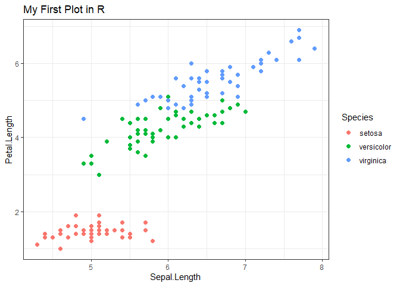

```r
ggplot(data = data, aes(x = Sepal.Length, y = Petal.Length, color = Species)) +
  geom_point(size = 2) +
  labs(title = "My First Plot in R") +
  theme_bw()
```

We can point the plot to an object and use it later:

```r
g <- ggplot(data = data, aes(x = Sepal.Length, y = Petal.Length, color = Species)) +
  geom_point(size = 2) +
  labs(title = "My First Plot in R") +
  theme_bw()
```

One of the advantages of doing that is to convert the static plot to an interactive plot using the library `Plotly` and the function `ggplotly`:

```r
plotly::ggplotly(g)
```

[interactive chart not shown]

## The “Pipe” (%>%) function

A very powerful tool in `R` is the **pipe** function, used as the symbol `%>%`. It works in a similar way as the `|` function in Linux: it sends the output of a command as an input in the next command.

```
cat file.txt | grep word
```

In `R`, the pipe function is used quite often and helps to make coding shorter and simpler. As an example, let’s save the names of the 4 first columns of the *iris* dataset to an object:

```r
names <- iris %>%
  colnames() %>%
  .[1:4]

print(names)
```

```
## [1] "Sepal.Length" "Sepal.Width"  "Petal.Length" "Petal.Width"
```

As another example, let’s do a clustering analysis of the *iris* dataset. We are going to use the flowers measurements to divide the data into groups (clusters) and check if they match the plant classification (“Species”). For this modeling, we will use the base function `kmeans` (run `?kmeans` in the console to learn more about this function). After, we will bind the results to the *iris* data, rename the column name, and convert this column to factor format:

```r
library(tidyverse)

# Create a cluster object
clusters = kmeans(
  x = iris[,names], # Only plant measurements from iris data
  centers = 3,      # Number of clusters
  iter.max = 100    # Max number of iterations
)

# Binding clusters to data
df <- iris %>%
  cbind(clusters$cluster) %>%
  rename(Cluster = "clusters$cluster") %>%
  mutate(Cluster = factor(Cluster))
```

Now we can plot and compare our results with the real categories:

```r
library(plotly)

g <- df %>%
  ggplot(aes(x = Sepal.Length, y = Petal.Length, color = Cluster)) +
  geom_point(size = 2) +
  theme_bw()

ggplotly(g)
```

[interactive chart not shown]

## Python in R

`Python` can be used directly from `R` thanks to the library [Reticulate](https://rstudio.github.io/reticulate/). To install it, run in your console:

```
install.packages("reticulate")
```

By importing it, you create a connection to your *python* installation:

```r
library(reticulate)
knitr::knit_engines$set(python = reticulate::eng_python)
```

After loading the library, you can create a chunk in python ({python}), and run it as in a `Jupyter Notebook`:

```python
import pandas as pd
import matplotlib.pyplot as plt
```

We can “transfer” data from `R` to `Python`, and vice-versa:

```python
df = r.data
df.head
```

```
## <bound method NDFrame.head of      Sepal.Length  Sepal.Width  Petal.Length  Petal.Width    Species
## 0             5.1          3.5           1.4          0.2     setosa
## 1             4.9          3.0           1.4          0.2     setosa
## 2             4.7          3.2           1.3          0.2     setosa
## 3             4.6          3.1           1.5          0.2     setosa
## 4             5.0          3.6           1.4          0.2     setosa
## ..            ...          ...           ...          ...        ...
## 145           6.7          3.0           5.2          2.3  virginica
## 146           6.3          2.5           5.0          1.9  virginica
## 147           6.5          3.0           5.2          2.0  virginica
## 148           6.2          3.4           5.4          2.3  virginica
## 149           5.9          3.0           5.1          1.8  virginica
##
## [150 rows x 5 columns]>
```

```python
my_name = "Marcelo"
```

```r
name <- py$my_name
print(name)
```

```
## [1] "Marcelo"
```

We can even do plots in python:

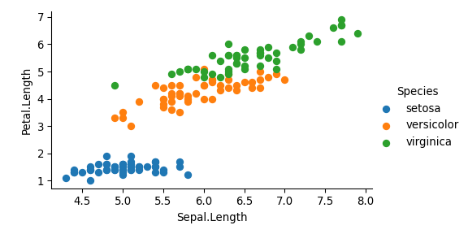

```python
import seaborn as sns
import os
import PyQt5
# os.environ['QT_QPA_PLATFORM_PLUGIN_PATH'] = 'c:/Users/marle/anaconda3/Library/plugins/platforms'

fg = sns.FacetGrid(data = df, hue = 'Species', aspect = 1.61)
fg.map(plt.scatter, 'Sepal.Length', 'Petal.Length').add_legend()
plt.show()
```

Or use the `python` functions directly in `R`:

```r
#importing required Python libraries/modules
sns <- import('seaborn')
plt <- import('matplotlib.pyplot')
pd <- import('pandas')

#building a seaborn pairplot using pairplot()
sns$pairplot(r_to_py(iris), hue = 'Species')

#display the plot
plt$show()
```

[output not shown]

## Other languages

### Bash

```bash
echo "Hello Bash!"
mkdir save_here
cp ./data/FL_insurance_sample.csv ./save_here/FL_insurance_sample.csv
```

```
## Hello Bash!
## mkdir: cannot create directory â€˜save_hereâ€™: File exists
```

### SQL

```r
library(DBI)
db = dbConnect(RSQLite::SQLite(), dbname = "data/chinook.db")
dbListTables(db)
```

```
##  [1] "albums"          "artists"         "customers"       "employees"
##  [5] "genres"          "invoice_items"   "invoices"        "media_types"
##  [9] "playlist_track"  "playlists"       "sqlite_sequence" "sqlite_stat1"
## [13] "tracks"
```

```sql
SELECT * FROM employees
```

8 records

| EmployeeId | LastName | FirstName | Title | ReportsTo | BirthDate | HireDate | Address | City | State | Country | PostalCode | Phone | Fax | Email |
| --- | --- | --- | --- | --- | --- | --- | --- | --- | --- | --- | --- | --- | --- | --- |
| 1 | Adams | Andrew | General Manager | NA | 1962-02-18 00:00:00 | 2002-08-14 00:00:00 | 11120 Jasper Ave NW | Edmonton | AB | Canada | T5K 2N1 | +1 (780) 428-9482 | +1 (780) 428-3457 | andrew@chinookcorp.com |
| 2 | Edwards | Nancy | Sales Manager | 1 | 1958-12-08 00:00:00 | 2002-05-01 00:00:00 | 825 8 Ave SW | Calgary | AB | Canada | T2P 2T3 | +1 (403) 262-3443 | +1 (403) 262-3322 | nancy@chinookcorp.com |
| 3 | Peacock | Jane | Sales Support Agent | 2 | 1973-08-29 00:00:00 | 2002-04-01 00:00:00 | 1111 6 Ave SW | Calgary | AB | Canada | T2P 5M5 | +1 (403) 262-3443 | +1 (403) 262-6712 | jane@chinookcorp.com |
| 4 | Park | Margaret | Sales Support Agent | 2 | 1947-09-19 00:00:00 | 2003-05-03 00:00:00 | 683 10 Street SW | Calgary | AB | Canada | T2P 5G3 | +1 (403) 263-4423 | +1 (403) 263-4289 | margaret@chinookcorp.com |
| 5 | Johnson | Steve | Sales Support Agent | 2 | 1965-03-03 00:00:00 | 2003-10-17 00:00:00 | 7727B 41 Ave | Calgary | AB | Canada | T3B 1Y7 | 1 (780) 836-9987 | 1 (780) 836-9543 | steve@chinookcorp.com |
| 6 | Mitchell | Michael | IT Manager | 1 | 1973-07-01 00:00:00 | 2003-10-17 00:00:00 | 5827 Bowness Road NW | Calgary | AB | Canada | T3B 0C5 | +1 (403) 246-9887 | +1 (403) 246-9899 | michael@chinookcorp.com |
| 7 | King | Robert | IT Staff | 6 | 1970-05-29 00:00:00 | 2004-01-02 00:00:00 | 590 Columbia Boulevard West | Lethbridge | AB | Canada | T1K 5N8 | +1 (403) 456-9986 | +1 (403) 456-8485 | robert@chinookcorp.com |
| 8 | Callahan | Laura | IT Staff | 6 | 1968-01-09 00:00:00 | 2004-03-04 00:00:00 | 923 7 ST NW | Lethbridge | AB | Canada | T1H 1Y8 | +1 (403) 467-3351 | +1 (403) 467-8772 | laura@chinookcorp.com |

```r
dbDisconnect(db)
```

### Rcpp (C++)

```cpp
#include <Rcpp.h>
using namespace Rcpp;

// [[Rcpp::export]]
NumericVector timesTwo(NumericVector x) {
  return x * 2;
}
```

```r
timesTwo(5)
```

[output not shown]

### CSS

```css
h3 {
  color: #F36170;
}
```